# NOAA Rainfall - Continued Analysis

Joy-El Talbot

6/3/2021

updated: 6/6/2021 by Joy-El

## Purpose

Quickly explore a new data set.

## Assumptions

1. HPCP *hourly rain data is in units of inches* having already been converted from hundredths of inches before we downloaded it.
2. HPCP 999.99 values represent missing data and will be *excluded* from the analysis.

### Table of Contents

1. Purpose
2. Project Setup
3. Analysis

### Appendices

1. Output Tables
2. Output ggplot Graphs
3. Output base-R Graphs

## Project Setup

### Directory Setup

```r
# TODO set eval=TRUE in line above to RUN this code
# TODO update as you desire for your directory
# TODO manually move data sources into the data/ folder
dir.create("data/")
dir.create("src/")
dir.create("analysis/")
dir.create("results/")
```

### Load Libaries

```r
library(ggplot2)
library(tidyr)
library(dplyr)
library(purrr) # part of tidyverse to get access to the map() function
```

### Define Constants

```r
# input source
DATADIR <- "data/"

# build results directory
ANALYSISNAME <- "noaa_rainfall"  # NO spaces!

DATESTAMP <- format(Sys.time(), "%Y-%m-%d-%H%M%S") # includes hours, minutes, and seconds if running multiple times in a day
RESULTSDIR <- paste0("results/",DATESTAMP,"-",ANALYSISNAME,"-results/")
dir.create(RESULTSDIR)
GRAPHDIR <- paste0(RESULTSDIR, "graphs/")
dir.create(GRAPHDIR)
TABLEDIR <- paste0(RESULTSDIR, "tables/")
dir.create(TABLEDIR)

# define default plot size
PLOT_WIDTH <- 5
PLOT_HEIGHT <- 5
PLOT_UNITS <- "in"
PLOT_RES <- 96 # required for png() device when units aren't "px"
```

### Load data

```r
rain <- utils::read.csv(paste0(DATADIR, "multicity_rain_noaa.csv"),
                        stringsAsFactors = FALSE)
```

## Analysis

### Initial Viewing

```r
head(rain)
```

```
##       STATION               STATION_NAME           DATE   HPCP
## 1 COOP:170100 ACADIA NATIONAL PARK ME US 20050101 00:00 999.99
## 2 COOP:170100 ACADIA NATIONAL PARK ME US 20050101 01:00 999.99
## 3 COOP:170100 ACADIA NATIONAL PARK ME US 20050111 14:00 999.99
## 4 COOP:170100 ACADIA NATIONAL PARK ME US 20050111 15:00 999.99
## 5 COOP:170100 ACADIA NATIONAL PARK ME US 20050111 16:00 999.99
## 6 COOP:170100 ACADIA NATIONAL PARK ME US 20050112 23:00   0.10
```

```r
rain[0:10,]
```

```
##        STATION               STATION_NAME           DATE   HPCP
## 1  COOP:170100 ACADIA NATIONAL PARK ME US 20050101 00:00 999.99
## 2  COOP:170100 ACADIA NATIONAL PARK ME US 20050101 01:00 999.99
## 3  COOP:170100 ACADIA NATIONAL PARK ME US 20050111 14:00 999.99
## 4  COOP:170100 ACADIA NATIONAL PARK ME US 20050111 15:00 999.99
## 5  COOP:170100 ACADIA NATIONAL PARK ME US 20050111 16:00 999.99
## 6  COOP:170100 ACADIA NATIONAL PARK ME US 20050112 23:00   0.10
## 7  COOP:170100 ACADIA NATIONAL PARK ME US 20050113 01:00   0.10
## 8  COOP:170100 ACADIA NATIONAL PARK ME US 20050117 04:00   0.10
## 9  COOP:170100 ACADIA NATIONAL PARK ME US 20050117 15:00   0.10
## 10 COOP:170100 ACADIA NATIONAL PARK ME US 20050118 20:00   0.10
```

```r
rain[2000:2010,]
```

```
##          STATION               STATION_NAME           DATE HPCP
## 2000 COOP:170100 ACADIA NATIONAL PARK ME US 20101117 12:00  0.2
## 2001 COOP:170100 ACADIA NATIONAL PARK ME US 20101117 13:00  0.3
## 2002 COOP:170100 ACADIA NATIONAL PARK ME US 20101117 17:00  0.1
## 2003 COOP:170100 ACADIA NATIONAL PARK ME US 20101122 15:00  0.1
## 2004 COOP:170100 ACADIA NATIONAL PARK ME US 20101123 16:00  0.1
## 2005 COOP:170100 ACADIA NATIONAL PARK ME US 20101126 08:00  0.1
## 2006 COOP:170100 ACADIA NATIONAL PARK ME US 20101126 10:00  0.1
## 2007 COOP:170100 ACADIA NATIONAL PARK ME US 20101126 13:00  0.1
## 2008 COOP:170100 ACADIA NATIONAL PARK ME US 20101201 01:00  0.0
## 2009 COOP:170100 ACADIA NATIONAL PARK ME US 20101202 01:00  0.1
## 2010 COOP:170100 ACADIA NATIONAL PARK ME US 20101202 02:00  0.2
```

```r
summary(rain)
```

```
##    STATION          STATION_NAME           DATE                HPCP
##  Length:12271       Length:12271       Length:12271       Min.   :   0.00
##  Class :character   Class :character   Class :character   1st Qu.:   0.00
##  Mode  :character   Mode  :character   Mode  :character   Median :   0.05
##                                                           Mean   :  12.14
##                                                           3rd Qu.:   0.10
##                                                           Max.   : 999.99
```

```r
unique(rain$STATION_NAME)
```

```
## [1] "ACADIA NATIONAL PARK ME US" "PORTLAND JETPORT ME US"
## [3] "ORONO 2 ME US"
```

### Data Cleanup

1. Convert 999.99 HPCP values to NA
2. Summarize to daily rainfall
3. Create day of year field in summary data

```r
# Step 1 - Convert 999.99 HPCP values to NA
clean_rain <- rain

clean_rain$HPCP[clean_rain$HPCP == 999.99] <- NA

summary(clean_rain)
```

```
##    STATION          STATION_NAME           DATE                HPCP
##  Length:12271       Length:12271       Length:12271       Min.   :0.00000
##  Class :character   Class :character   Class :character   1st Qu.:0.00000
##  Mode  :character   Mode  :character   Mode  :character   Median :0.04000
##                                                           Mean   :0.07598
##                                                           3rd Qu.:0.10000
##                                                           Max.   :1.40000
##                                                           NA's   :148
```

```r
clean_rain <- clean_rain[!is.na(clean_rain$HPCP), ]

summary(clean_rain)
```

```
##    STATION          STATION_NAME           DATE                HPCP
##  Length:12123       Length:12123       Length:12123       Min.   :0.00000
##  Class :character   Class :character   Class :character   1st Qu.:0.00000
##  Mode  :character   Mode  :character   Mode  :character   Median :0.04000
##                                                           Mean   :0.07598
##                                                           3rd Qu.:0.10000
##                                                           Max.   :1.40000
```

#### Some notes about the HPCP column

According to the [data documentation from NOAA](https://www1.ncdc.noaa.gov/pub/data/cdo/documentation/PRECIP_HLY_documentation.pdf), the HPCP column is originally gathered as hundreths of inches of rainfall. The 99999 value is used to represent missing data values.

Given the format of the 99999 value in our imported data as 999.99, we ASSUME that the data has been converted to inches by dividing all HPCP values by 100.

```r
# Step 1b - determine units of HPCP and name accordingly
clean_rain <- rename(clean_rain, inchesRain = HPCP)
head(clean_rain)
```

```
##        STATION               STATION_NAME           DATE inchesRain
## 6  COOP:170100 ACADIA NATIONAL PARK ME US 20050112 23:00        0.1
## 7  COOP:170100 ACADIA NATIONAL PARK ME US 20050113 01:00        0.1
## 8  COOP:170100 ACADIA NATIONAL PARK ME US 20050117 04:00        0.1
## 9  COOP:170100 ACADIA NATIONAL PARK ME US 20050117 15:00        0.1
## 10 COOP:170100 ACADIA NATIONAL PARK ME US 20050118 20:00        0.1
## 11 COOP:170100 ACADIA NATIONAL PARK ME US 20050120 01:00        0.1
```

```r
# Step 2 - Summarize to daily rainfall

# Step 2a - get date string from timestamp
clean_rain$day <- as.character(map(strsplit(clean_rain$DATE, " "), 1))

# Step 2b - group by date string and sum inchesRain to get daily rainfall
rain_summary <- clean_rain %>%
  group_by(day) %>%
  dplyr::summarise(dailyRainInches = sum(inchesRain))

rain_summary$year <- substr(rain_summary$day, 0, 4)
```

```r
# create field for day of year number
rain_summary$date <- as.Date(rain_summary$day, format = "%Y%m%d")

# strftime() solution from stackoverflow, hat-tip @Gavin Simpson; https://stackoverflow.com/questions/7958298/how-do-you-convert-posix-date-to-day-of-year
rain_summary$dayOfYear <- strftime(rain_summary$date, format = "%j") %>%
                            as.numeric()
head(rain_summary)
```

```
## # A tibble: 6 x 5
##   day      dailyRainInches year  date       dayOfYear
##   <chr>              <dbl> <chr> <date>         <dbl>
## 1 20050101            0    2005  2005-01-01         1
## 2 20050102            0.27 2005  2005-01-02         2
## 3 20050103            0.14 2005  2005-01-03         3
## 4 20050104            0.19 2005  2005-01-04         4
## 5 20050106            0.47 2005  2005-01-06         6
## 6 20050107            0.01 2005  2005-01-07         7
```

### Explore Data via Daily Rain field

#### Plot average daily rainfall by year

```r
df_plot <- rain_summary %>%
  group_by(year) %>%
  dplyr::summarise(averageDailyRain = mean(dailyRainInches)) %>%
  arrange(desc(averageDailyRain))

head(df_plot)
```

```
## # A tibble: 6 x 2
##   year  averageDailyRain
##   <chr>            <dbl>
## 1 2009             0.800
## 2 2010             0.778
## 3 2007             0.754
## 4 2006             0.751
## 5 2005             0.741
## 6 2008             0.686
```

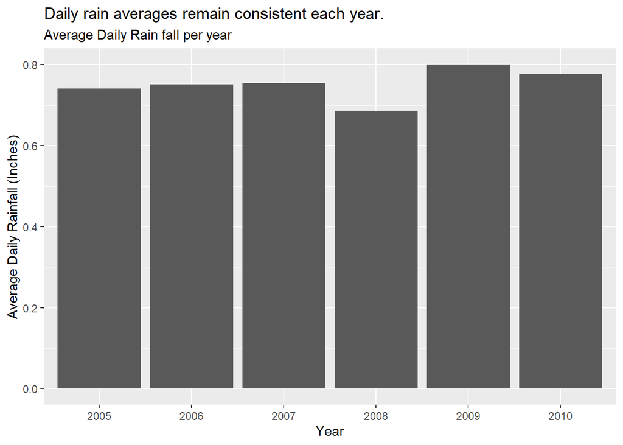

```r
write.csv(df_plot,
          file = paste0(TABLEDIR,"aveDailyRainbyYear.csv"),
          row.names = FALSE)

(ggplot(df_plot)
  # reorder() orders first field according to order of second field
  #   defaults to ascending order on second field
  #     override with desc() function around second field
 #+ aes(x = reorder(as.character(year), desc(averageDailyRain)), y = averageDailyRain)
 + aes(x = as.character(year), y = averageDailyRain)
 + geom_bar(stat = "identity")
 + ggtitle(label = "Daily rain averages remain consistent each year.",
           subtitle = "Average Daily Rain fall per year")
 + scale_x_discrete("Year")
 + scale_y_continuous("Average Daily Rainfall (Inches)")
 )
```

```r
ggsave(filename = paste0(GRAPHDIR, "aveDailyRainbyYear.png"),
       width = PLOT_WIDTH,
       height = PLOT_HEIGHT,
       units = PLOT_UNITS)
```

#### Plot daily rainfall across each year

Goal: view line graph of daily rainfall for each year x-axis = days of year y-axis = total rain in inches group = color-code by year, maybe facet

Recommended reading - [examples of boxplots & jitterplots](https://cmdlinetips.com/2019/02/how-to-make-grouped-boxplots-with-ggplot2/)

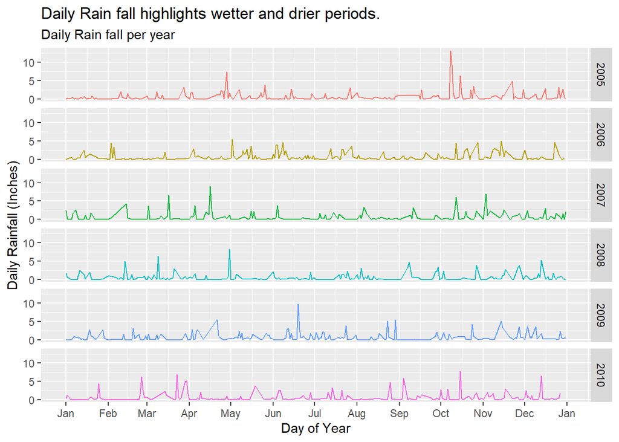

```r
df_plot <- rain_summary
df_plot$unifiedDate <- as.Date(strptime(df_plot$dayOfYear, format = "%j"))

(ggplot(df_plot)
 + aes(x = unifiedDate,
       y = dailyRainInches,
       group = year)
 + geom_line(aes(color = year))
 + facet_grid(year ~ .)
 + theme(legend.position = "none")
 + ggtitle(label = "Daily Rain fall highlights wetter and drier periods.",
           subtitle = "Daily Rain fall per year")
 + scale_x_date("Day of Year",
                date_labels = "%b",
                date_breaks = "1 month")
 + scale_y_continuous("Daily Rainfall (Inches)")
 )
```

```r
# Finding it hard to identify patterns in the time series (too much noise, eg.
# too much variability). Instead going to try plotting as boxplots to condense
# down the variability and facilitate comparisons.

df_plot$month <- strftime(df_plot$unifiedDate, format = "%b")
df_plot$month <- factor(df_plot$month,
                        levels = c("Jan", "Feb", "Mar", "Apr",
                                   "May", "Jun", "Jul", "Aug",
                                   "Sep", "Oct", "Nov", "Dec"),
                        ordered = TRUE)
head(df_plot)
```

```
## # A tibble: 6 x 7
##   day      dailyRainInches year  date       dayOfYear unifiedDate month
##   <chr>              <dbl> <chr> <date>         <dbl> <date>      <ord>
## 1 20050101            0    2005  2005-01-01         1 2021-01-01  Jan
## 2 20050102            0.27 2005  2005-01-02         2 2021-01-02  Jan
## 3 20050103            0.14 2005  2005-01-03         3 2021-01-03  Jan
## 4 20050104            0.19 2005  2005-01-04         4 2021-01-04  Jan
## 5 20050106            0.47 2005  2005-01-06         6 2021-01-06  Jan
## 6 20050107            0.01 2005  2005-01-07         7 2021-01-07  Jan
```

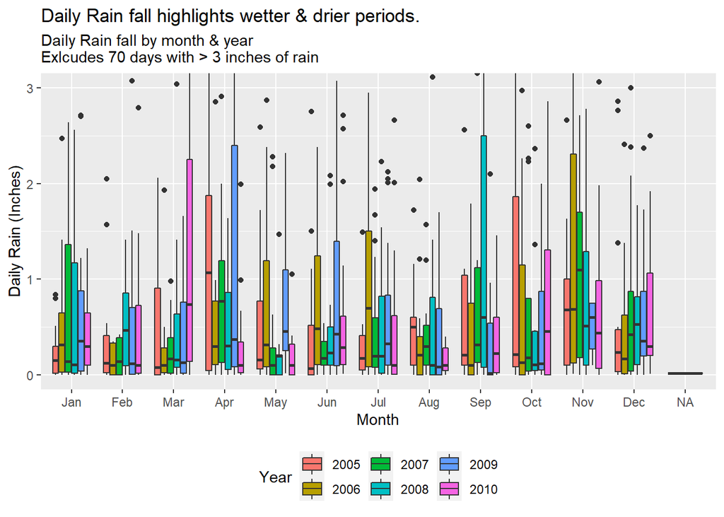

```r
(ggplot(df_plot)
  + aes(x = month,
        y = dailyRainInches,
        fill = factor(year))
  + geom_boxplot()
  + scale_x_discrete("Month")
  + scale_y_continuous("Daily Rain (Inches)")
  + coord_cartesian(ylim = c(0,3))
  + ggtitle(label = "Daily Rain fall highlights wetter & drier periods.",
            subtitle = paste0("Daily Rain fall by month & year\nExlcudes ",
                              sum(rain_summary$dailyRainInches > 3),
                              " days with > 3 inches of rain"))
  + scale_fill_discrete("Year")
  + theme(legend.position = "bottom")
  )
```

```r
ggsave(filename = paste0(GRAPHDIR, "dailyRainbyMonthYear_boxplot.png"),
       width = PLOT_WIDTH*2,
       height = PLOT_HEIGHT,
       units = PLOT_UNITS)
```

#### Compare plot types - histogram, bar graph, and boxplot

Purpose: show the same (or as close the same as possible) data with all three plot types.

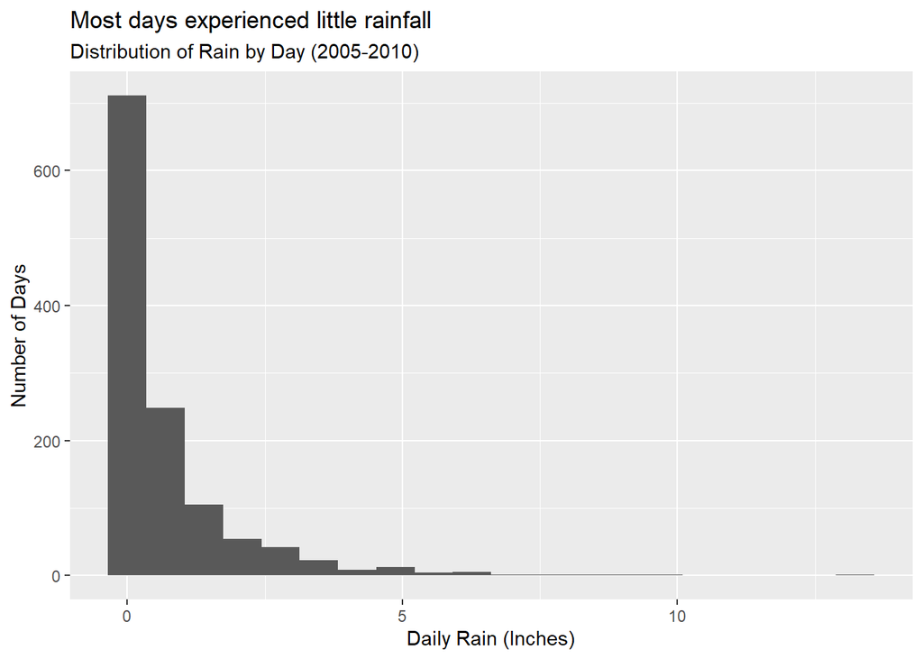

```r
# Histogram shows frequency of each value for a continuous variable
#  in this case, dailyRainInches from the rain_summary table will be our continuous variable
(ggplot(rain_summary)
 + aes(x = dailyRainInches)
 + geom_histogram(bins = 20) # I chose 20 pretty arbitrarily
 + scale_x_continuous("Daily Rain (Inches)")
 + scale_y_continuous("Number of Days")
 + ggtitle("Most days experienced little rainfall",
           subtitle = "Distribution of Rain by Day (2005-2010)")
 )
```

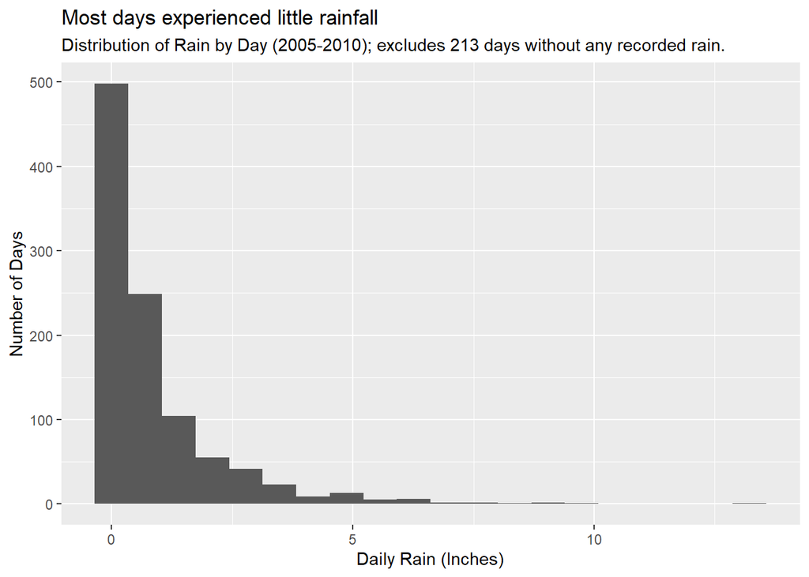

```r
ggsave(filename = paste0(GRAPHDIR, "dailyRain_hist.png"),
       width = PLOT_WIDTH*2,
       height = PLOT_HEIGHT,
       units = PLOT_UNITS)

# let's exclude days with NO rain
no_rain_days <- sum(rain_summary$dailyRainInches == 0)
(ggplot(rain_summary[rain_summary$dailyRainInches > 0, ])
 + aes(x = dailyRainInches)
 + geom_histogram(bins = 20) # I chose 20 pretty arbitrarily
 + scale_x_continuous("Daily Rain (Inches)")
 + scale_y_continuous("Number of Days")
 + ggtitle("Most days experienced little rainfall",
           subtitle = paste0("Distribution of Rain by Day (2005-2010); excludes ",
                             no_rain_days,
                             " days without any recorded rain."))
 )
```

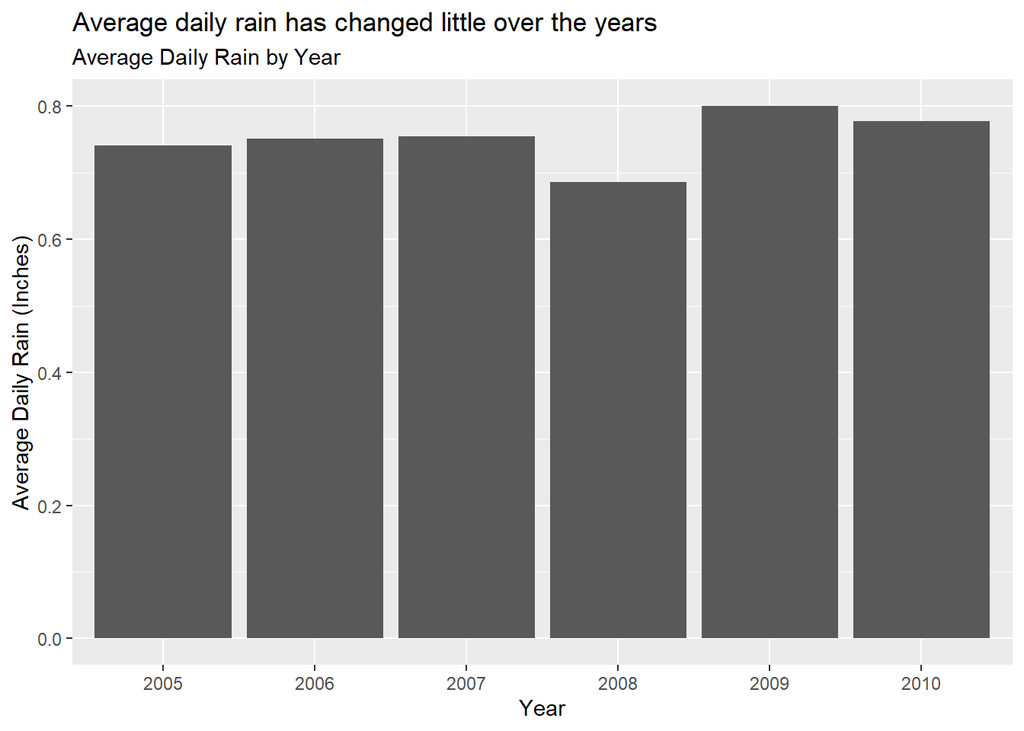

```r
ggsave(filename = paste0(GRAPHDIR, "dailyRain_excludeNoRain_hist.png"),
       width = PLOT_WIDTH*2,
       height = PLOT_HEIGHT,
       units = PLOT_UNITS)

# Bar graph shows a summary (typically count or average) of a continuous variable
# across multiple categorical values.
#   in this case, dailyRainInches will be our continuous variable, year will be our
#   categorical, and we will show the average dailyRain for each year.

# geom_bar defaults to counting each item provided, to get other types of summaries
# we need to do these ourselves.
df_plot <- rain_summary %>%
  group_by(year) %>%
  summarise(aveRain = mean(dailyRainInches))

(ggplot(df_plot)
  + aes(x = year, y = aveRain)
  + geom_bar(stat = "identity") # sending stat "identity" to tell ggplot to use the raw values
  + scale_x_discrete("Year")
  + scale_y_continuous("Average Daily Rain (Inches)")
  + ggtitle("Average daily rain has changed little over the years",
            subtitle = "Average Daily Rain by Year")
  )
```

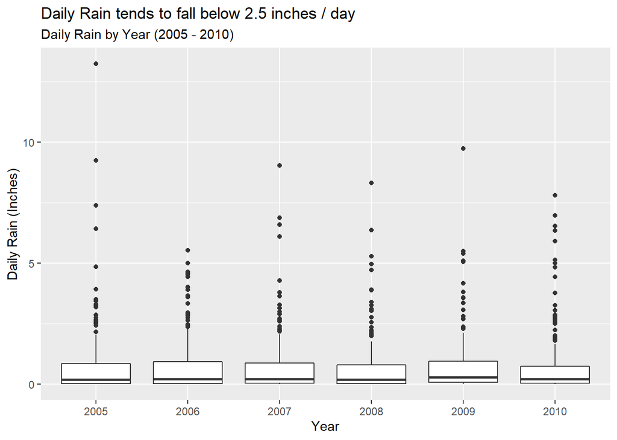

```r
ggsave(filename = paste0(GRAPHDIR, "dailyRainByYear_bar.png"),
       width = PLOT_WIDTH*2,
       height = PLOT_HEIGHT,
       units = PLOT_UNITS)

# Boxplots summarize the distribution of a continuous variable (specifically
# median, IQR, and 1.5 IQR) across the entire dataset (one boxplot) or for multiple
# categorical values.
#   in this case, dailyRainInches will be our continuous variable, year will be our
#   categorical

(ggplot(rain_summary)
  + aes(x = year, y = dailyRainInches)
  + geom_boxplot()
  + scale_x_discrete("Year")
  + scale_y_continuous("Daily Rain (Inches)")
  + ggtitle("Daily Rain tends to fall below 2.5 inches / day",
            subtitle = "Daily Rain by Year (2005 - 2010)")
  )
```

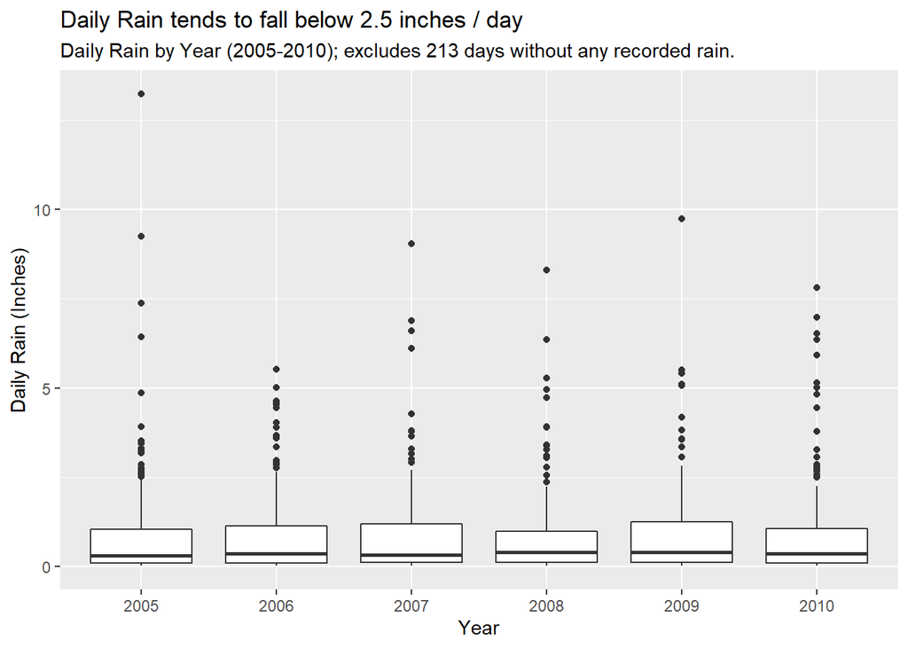

```r
ggsave(filename = paste0(GRAPHDIR, "dailyRainByYear_box.png"),
       width = PLOT_WIDTH*2,
       height = PLOT_HEIGHT,
       units = PLOT_UNITS)

# let's exclude days with NO rain
no_rain_days <- sum(rain_summary$dailyRainInches == 0)
(ggplot(rain_summary[rain_summary$dailyRainInches > 0, ])
  + aes(x = year, y = dailyRainInches)
  + geom_boxplot()
  + scale_x_discrete("Year")
  + scale_y_continuous("Daily Rain (Inches)")
  + ggtitle("Daily Rain tends to fall below 2.5 inches / day",
            subtitle = paste0("Daily Rain by Year (2005-2010); excludes ",
                             no_rain_days,
                             " days without any recorded rain."))
 )
```

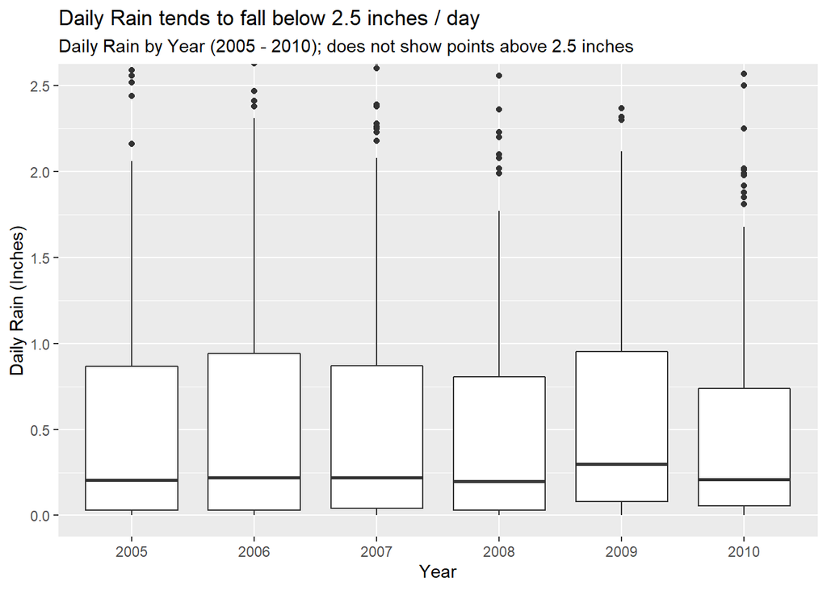

```r
ggsave(filename = paste0(GRAPHDIR, "dailyRainByYear_excludeNoRain_box.png"),
       width = PLOT_WIDTH*2,
       height = PLOT_HEIGHT,
       units = PLOT_UNITS)

# Let's go back to the first box plot, but zoom in on the boxes
(ggplot(rain_summary)
  + aes(x = year, y = dailyRainInches)
  + geom_boxplot()
  + scale_x_discrete("Year")
  + scale_y_continuous("Daily Rain (Inches)")
  + ggtitle("Daily Rain tends to fall below 2.5 inches / day",
            subtitle = "Daily Rain by Year (2005 - 2010); does not show points above 2.5 inches")
  + coord_cartesian(ylim = c(0, 2.5))
  )
```

```r
ggsave(filename = paste0(GRAPHDIR, "dailyRainByYear_zoomed_box.png"),
       width = PLOT_WIDTH*2,
       height = PLOT_HEIGHT,
       units = PLOT_UNITS)
```

## Appendix - Examples for Outputting code

TODO Feel free to remove if desired

### Output Tables

```r
byYear <- checkouts %>%
  group_by(CheckoutYear) %>%
  summarise(Count = n())
print(byYear)

write.csv(byYear,
          file = paste0(TABLEDIR,"Checkouts_by_year.csv"),
          row.names = FALSE) # to suppress row.names of 1, 2, 3...
```

- `write.csv` ensures formatting of output matches CSV file standards
- `write.table` gives more flexiblity but usually not needed
- Other commands for writing JSON, XML, and other formats can be found with a quick search (and usually a library() package).

### Output Graph Images

#### With ggplot2

```r
# wrap in parentheses so the "+" signs are a the left, making it easier to comment out lines
(ggplot(checkouts)
+ aes(x = factor(CheckoutYear))  # adding factor() so these names become x-axis label names
+ geom_bar()
+ ggtitle("Patrons checkout fewer books in 2020")
+ labs(subtitle = "Seattle Public Library - Physical Book Checkouts")
+ scale_y_continuous("Physical Books Checked Out\n(2% sample)")
#+ scale_x_discrete("") # no label
+ scale_x_discrete("Year")
)

# saves the last image you plotted to file by default
# OTHERWISE you can pass a ggplot object to the plot= argument
ggsave(filename = paste0(GRAPHDIR,"ggplot_CheckoutsByYear.png"),
       width = PLOT_WIDTH*0.9, # add multipliers to make image a little bigger or smaller as needed (if needed)
       height = PLOT_HEIGHT*1.1,
       units = PLOT_UNITS)
```

- Graph first, then save after (similar to table output workflow)
- `ggsave()` will write the last plot to file
- Setting constants for plot size makes it easy to keep images of consistent size
- Nudge size larger or smaller with a size multiplier to the PLOT_WIDTH or PLOT_HEIGHT constants

#### With base R plots

```r
# open output file
png(filename = paste0(GRAPHDIR,"basePlot_CheckoutsByYear.png"),
    width = PLOT_WIDTH,
    height = PLOT_HEIGHT,
    units = PLOT_UNITS,
    res = PLOT_RES)

# create plot
hist(x = checkouts$CheckoutYear,
     main = "Patrons checkout fewer books in 2020",
     sub = "Seattle Public Library - Physical Book Checkouts",
     xlab = "Year",
     ylab = "Physical Books Checked Out\n(2% sample)")

# close the output device
dev.off()
```

- Sandwich file-saving code around the graph-building code
- If your graph building errors out, you may leave “devices” open
  - Avoid by testing graph code first (without opening a device)
  - Fix by repeatedly run dev.off() in the console